# play ground

# Libraries and environment

Load libraries ans set the seed.

```r
library(tidyverse)
library(data.table)
library(caret)
library(rattle)
set.seed(19930212)
```

# Load data

Load data into R

```r
# train_url <- "https://d396qusza40orc.cloudfront.net/predmachlearn/pml-training.csv"
# test_url <- "https://d396qusza40orc.cloudfront.net/predmachlearn/pml-testing.csv"
#
# raw_train <- fread(train_url)
# raw_test <- fread(test_url)
```

# Feature selection

## Cleaning the data

```r
# Create a new dataframe for training
training <- as.data.frame(raw_train)

# clean the data

# turn the classe column into a factor
training$classe <- factor(training$classe)

# turn all integers into numeric
for (i in colnames(training)){
  class_i <- class(training[[i]])
  if(class_i == "integer"){training[[i]] <- as.numeric(training[[i]])}
}

# how many features are there?
dim(training)
```

```
[1] 19622   160
```

## Removing zero covariates

```r
# check for near zero variance
nsv <- nearZeroVar(training, saveMetrics = TRUE)
nsv[nsv$nzv == TRUE,]
```

|  | freqRatio | percentUnique | zeroVar | nzv |
| --- | --- | --- | --- | --- |
| new_window | 47.33005 | 0.01019264 | FALSE | TRUE |
| kurtosis_yaw_belt | 0.00000 | 0.00000000 | TRUE | TRUE |
| skewness_yaw_belt | 0.00000 | 0.00000000 | TRUE | TRUE |
| amplitude_yaw_belt | 0.00000 | 0.00509632 | TRUE | TRUE |
| avg_roll_arm | 77.00000 | 1.68178575 | FALSE | TRUE |
| stddev_roll_arm | 77.00000 | 1.68178575 | FALSE | TRUE |
| var_roll_arm | 77.00000 | 1.68178575 | FALSE | TRUE |
| avg_pitch_arm | 77.00000 | 1.68178575 | FALSE | TRUE |
| stddev_pitch_arm | 77.00000 | 1.68178575 | FALSE | TRUE |
| var_pitch_arm | 77.00000 | 1.68178575 | FALSE | TRUE |

[output cut: 26 more lines]

```r
# remove the columns with near zero variances
drop_cols <- rownames(nsv[nsv$nzv == TRUE,])
training <- training %>% select(-drop_cols)

# how many features are there?
dim(training)
```

```
[1] 19622   124
```

## Remove missing values

The data has some columns with many missing values. Generally, the columns that look to be summary level statistics are missing values in most cases (e.g. columns starting with max, min, var, etc.)

```r
# total missing values
sum(is.na(training))
```

```
[1] 1250007
```

```r
# missing values by column
sapply(training, function(x) sum(is.na(x))/nrow(training))
```

```
                      V1                user_name     raw_timestamp_part_1     raw_timestamp_part_2           cvtd_timestamp
               0.0000000                0.0000000                0.0000000                0.0000000                0.0000000
              num_window                roll_belt               pitch_belt                 yaw_belt         total_accel_belt
               0.0000000                0.0000000                0.0000000                0.0000000                0.0000000
      kurtosis_roll_belt      kurtosis_picth_belt       skewness_roll_belt     skewness_roll_belt.1            max_roll_belt
               0.9798186                0.9809398                0.9797676                0.9809398                0.9793089
          max_picth_belt             max_yaw_belt            min_roll_belt           min_pitch_belt             min_yaw_belt
               0.9793089                0.9798186                0.9793089                0.9793089                0.9798186
     amplitude_roll_belt     amplitude_pitch_belt     var_total_accel_belt            avg_roll_belt         stddev_roll_belt
               0.9793089                0.9793089                0.9793089                0.9793089                0.9793089
           var_roll_belt           avg_pitch_belt        stddev_pitch_belt           var_pitch_belt             avg_yaw_belt
               0.9793089                0.9793089                0.9793089                0.9793089                0.9793089
         stddev_yaw_belt             var_yaw_belt             gyros_belt_x             gyros_belt_y             gyros_belt_z
               0.9793089                0.9793089                0.0000000                0.0000000                0.0000000
            accel_belt_x             accel_belt_y             accel_belt_z            magnet_belt_x            magnet_belt_y
               0.0000000                0.0000000                0.0000000                0.0000000                0.0000000
           magnet_belt_z                 roll_arm                pitch_arm                  yaw_arm          total_accel_arm
               0.0000000                0.0000000                0.0000000                0.0000000                0.0000000
           var_accel_arm              gyros_arm_x              gyros_arm_y              gyros_arm_z              accel_arm_x
               0.9793089                0.0000000                0.0000000                0.0000000                0.0000000
             accel_arm_y              accel_arm_z             magnet_arm_x             magnet_arm_y             magnet_arm_z
               0.0000000                0.0000000                0.0000000                0.0000000                0.0000000
       kurtosis_roll_arm       kurtosis_picth_arm         kurtosis_yaw_arm        skewness_roll_arm       skewness_pitch_arm
               0.9832841                0.9833860                0.9798695                0.9832331                0.9833860
        skewness_yaw_arm            max_picth_arm              max_yaw_arm              min_yaw_arm        amplitude_yaw_arm
               0.9798695                0.9793089                0.9793089                0.9793089                0.9793089
           roll_dumbbell           pitch_dumbbell             yaw_dumbbell   kurtosis_roll_dumbbell  kurtosis_picth_dumbbell
               0.0000000                0.0000000                0.0000000                0.9795638                0.9794109
  skewness_roll_dumbbell  skewness_pitch_dumbbell        max_roll_dumbbell       max_picth_dumbbell         max_yaw_dumbbell
               0.9795128                0.9793599                0.9793089                0.9793089                0.9795638
       min_roll_dumbbell       min_pitch_dumbbell         min_yaw_dumbbell  amplitude_roll_dumbbell amplitude_pitch_dumbbell
               0.9793089                0.9793089                0.9795638                0.9793089                0.9793089
    total_accel_dumbbell       var_accel_dumbbell        avg_roll_dumbbell     stddev_roll_dumbbell        var_roll_dumbbell
```

[output cut: 17 more lines]

```r
# Remove columns that do not have enough data. We will remove any column that does not have data for at least 95% of observations.
greater_than_95 <- sapply(training, function(x) sum(is.na(x))/nrow(training)<0.05)
training <- training[, greater_than_95]

# how many features are there?
dim(training)
```

```
[1] 19622    59
```

## Remove specific columns

Remove specific features that are not relevant:

- “V1” should be removed as it is an index and is random
- “user_name” should be removed since we want to predict the outcome based on the sensor data, not the person performing the exercise
- “raw_timestamp_part_1”, “raw_timestamp_part_2”, “cvtd_timestamp”, “new_window”, and “num_window” should all be removed because they are timestamps, and do not have any meaningful relationship to how well the movement was performed
- any column that starts with “total” because it is summary statistic and not capturing the same level of detail as the rest of the data

```r
# drop selected columns
drop_cols <- c("V1", "user_name", "raw_timestamp_part_1", "raw_timestamp_part_2", "cvtd_timestamp", "new_window", "num_window")
training <- training %>% select(-one_of(drop_cols))
```

```
Unknown columns: `new_window`
```

```r
# remove columns that start with "total"
training <- training %>% select(-starts_with("total"))

# how many features are there?
dim(training)
```

```
[1] 19622    49
```

## Selected features

Our model will use the following features.

```r
str(training)
```

```
'data.frame':   19622 obs. of  49 variables:
 $ roll_belt        : num  1.41 1.41 1.42 1.48 1.48 1.45 1.42 1.42 1.43 1.45 ...
 $ pitch_belt       : num  8.07 8.07 8.07 8.05 8.07 8.06 8.09 8.13 8.16 8.17 ...
 $ yaw_belt         : num  -94.4 -94.4 -94.4 -94.4 -94.4 -94.4 -94.4 -94.4 -94.4 -94.4 ...
 $ gyros_belt_x     : num  0 0.02 0 0.02 0.02 0.02 0.02 0.02 0.02 0.03 ...
 $ gyros_belt_y     : num  0 0 0 0 0.02 0 0 0 0 0 ...
 $ gyros_belt_z     : num  -0.02 -0.02 -0.02 -0.03 -0.02 -0.02 -0.02 -0.02 -0.02 0 ...
 $ accel_belt_x     : num  -21 -22 -20 -22 -21 -21 -22 -22 -20 -21 ...
 $ accel_belt_y     : num  4 4 5 3 2 4 3 4 2 4 ...
 $ accel_belt_z     : num  22 22 23 21 24 21 21 21 24 22 ...
 $ magnet_belt_x    : num  -3 -7 -2 -6 -6 0 -4 -2 1 -3 ...
 $ magnet_belt_y    : num  599 608 600 604 600 603 599 603 602 609 ...
 $ magnet_belt_z    : num  -313 -311 -305 -310 -302 -312 -311 -313 -312 -308 ...
 $ roll_arm         : num  -128 -128 -128 -128 -128 -128 -128 -128 -128 -128 ...
 $ pitch_arm        : num  22.5 22.5 22.5 22.1 22.1 22 21.9 21.8 21.7 21.6 ...
```

[output cut: 35 more lines]

# Cross validation

Partition the training data into a subset so we can better estimate the out of sample error rate

```r
inTrain <- createDataPartition(y = training$classe, p = 0.75, list = FALSE)
training_train <- training[inTrain,]
training_test <- training[-inTrain,]
```

# Model #1: Classificaiton Tree (rpart)

## Build the model

```r
# fit the model
model_1 <- rpart::rpart(classe ~ .,
                 data = training_train,
                 method = "class")
```

## View the model

```r
# view model
model_1
```

```
n= 14718

node), split, n, loss, yval, (yprob)
      * denotes terminal node

   1) root 14718 10533 A (0.28 0.19 0.17 0.16 0.18)
     2) roll_belt< 130.5 13473  9302 A (0.31 0.21 0.19 0.18 0.11)
       4) pitch_forearm< -33.95 1184    10 A (0.99 0.0084 0 0 0) *
       5) pitch_forearm>=-33.95 12289  9292 A (0.24 0.23 0.21 0.2 0.12)
        10) magnet_dumbbell_y< 439.5 10406  7473 A (0.28 0.18 0.24 0.19 0.11)
          20) roll_forearm< 123.5 6455  3830 A (0.41 0.18 0.18 0.17 0.058)
            40) magnet_dumbbell_z< -27.5 2167   721 A (0.67 0.21 0.013 0.079 0.03) *
            41) magnet_dumbbell_z>=-27.5 4288  3109 A (0.27 0.17 0.27 0.22 0.072)
              82) accel_dumbbell_y>=-40.5 3766  2590 A (0.31 0.18 0.19 0.24 0.076)
               164) yaw_belt>=169.5 508    57 A (0.89 0.041 0 0.069 0.002) *
               165) yaw_belt< 169.5 3258  2378 D (0.22 0.2 0.21 0.27 0.088)
                 330) pitch_belt< -43.15 371    52 B (0.016 0.86 0.059 0.04 0.024) *
                 331) pitch_belt>=-43.15 2887  2022 D (0.25 0.12 0.23 0.3 0.096)
                   662) roll_belt>=125.5 676   288 C (0.37 0.034 0.57 0.015 0.0044)
                    1324) magnet_belt_z< -322.5 226     9 A (0.96 0.0044 0.022 0 0.013) *
                    1325) magnet_belt_z>=-322.5 450    67 C (0.078 0.049 0.85 0.022 0) *
                   663) roll_belt< 125.5 2211  1356 D (0.21 0.15 0.13 0.39 0.12)
                    1326) yaw_belt< -87.05 1234   888 A (0.28 0.23 0.15 0.2 0.14)
                      2652) yaw_forearm>=-95.15 971   625 A (0.36 0.27 0.15 0.06 0.16)
                        5304) magnet_forearm_z>=-43.5 440   123 A (0.72 0.15 0.0068 0.032 0.095) *
                        5305) magnet_forearm_z< -43.5 531   332 B (0.055 0.37 0.27 0.083 0.22) *
                      2653) yaw_forearm< -95.15 263    77 D (0 0.068 0.17 0.71 0.057) *
                    1327) yaw_belt>=-87.05 977   366 D (0.12 0.045 0.1 0.63 0.1)
                      2654) yaw_arm< -109 112     0 A (1 0 0 0 0) *
                      2655) yaw_arm>=-109 865   254 D (0.01 0.051 0.11 0.71 0.12) *
              83) accel_dumbbell_y< -40.5 522    61 C (0.0057 0.038 0.88 0.029 0.044) *
          21) roll_forearm>=123.5 3951  2659 C (0.078 0.18 0.33 0.23 0.18)
            42) accel_forearm_x>=-107.5 2789  1762 C (0.087 0.22 0.37 0.11 0.21)
              84) magnet_forearm_z< -245 239    56 A (0.77 0.18 0 0.046 0.0042) *
              85) magnet_forearm_z>=-245 2550  1523 C (0.024 0.23 0.4 0.11 0.23)
               170) magnet_dumbbell_y< 261.5 1295   528 C (0.031 0.17 0.59 0.084 0.12) *
               171) magnet_dumbbell_y>=261.5 1255   816 E (0.017 0.29 0.21 0.14 0.35)
                 342) magnet_arm_y>=186 552   296 B (0.022 0.46 0.3 0.078 0.13) *
                 343) magnet_arm_y< 186 703   337 E (0.013 0.15 0.13 0.19 0.52) *
            43) accel_forearm_x< -107.5 1162   557 D (0.055 0.086 0.23 0.52 0.11)
              86) magnet_arm_y>=291.5 355   141 C (0.039 0.12 0.6 0.16 0.076) *
              87) magnet_arm_y< 291.5 807   260 D (0.062 0.072 0.063 0.68 0.13) *
        11) magnet_dumbbell_y>=439.5 1883   933 B (0.034 0.5 0.046 0.22 0.2)
          22) accel_dumbbell_y>=46.5 1300   481 B (0.049 0.63 0.065 0.016 0.24)
            44) roll_belt>=-0.58 1087   268 B (0.059 0.75 0.077 0.019 0.091) *
            45) roll_belt< -0.58 213     0 E (0 0 0 0 1) *
          23) accel_dumbbell_y< 46.5 583   195 D (0 0.22 0.0034 0.67 0.11)
            46) yaw_belt< -2.825 120     0 B (0 1 0 0 0) *
            47) yaw_belt>=-2.825 463    75 D (0 0.024 0.0043 0.84 0.13) *
     3) roll_belt>=130.5 1245    14 E (0.011 0 0 0 0.99) *
```

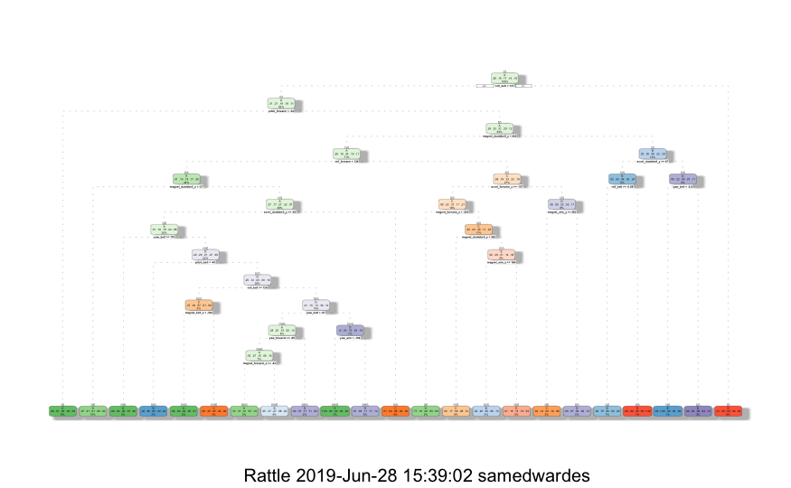

```r
# plot model
fancyRpartPlot(model_1)
```

## Assess the model results

Predict using the training data that was set aside

```r
predict1 <- predict(model_1, newdata = training_test, type = "class")
table(predict1)
```

```
predict1
   A    B    C    D    E
1621  917  868  787  711
```

Confusion matrix

```r
confusionMatrix(predict1, training_test$classe)
```

```
Confusion Matrix and Statistics

          Reference
Prediction    A    B    C    D    E
         A 1300  209   14   68   30
         B   40  568  137   59  113
         C   30  107  607   65   59
         D   22   39   64  562  100
         E    3   26   33   50  599

Overall Statistics

               Accuracy : 0.7414
                 95% CI : (0.7289, 0.7536)
    No Information Rate : 0.2845
    P-Value [Acc > NIR] : < 2.2e-16

                  Kappa : 0.671

 Mcnemar's Test P-Value : < 2.2e-16

Statistics by Class:

                     Class: A Class: B Class: C Class: D Class: E
Sensitivity            0.9319   0.5985   0.7099   0.6990   0.6648
Specificity            0.9085   0.9118   0.9355   0.9451   0.9720
Pos Pred Value         0.8020   0.6194   0.6993   0.7141   0.8425
Neg Pred Value         0.9711   0.9044   0.9386   0.9412   0.9280
Prevalence             0.2845   0.1935   0.1743   0.1639   0.1837
Detection Rate         0.2651   0.1158   0.1238   0.1146   0.1221
Detection Prevalence   0.3305   0.1870   0.1770   0.1605   0.1450
Balanced Accuracy      0.9202   0.7551   0.8227   0.8221   0.8184
```